# Initial exploration of GTD

Peter B

1 November 2016

## R Markdown

We will be using these packages over the course of the experiment

```r
library(purrr)
library(rts)
library(depmixS4)
library(TTR)
library(ggplot2)
library(reshape2)
library(gridExtra)
library(dplyr)
library(ggplot2)
library(tidyr)
library(lubridate)
library(KMsurv)
library(tibble)
library(stringr)
```

## Terrorism over time by regioon and world wide figures

The time series plot for the different regions is shown below. The temporal, regional relationships described above are clearly visible.

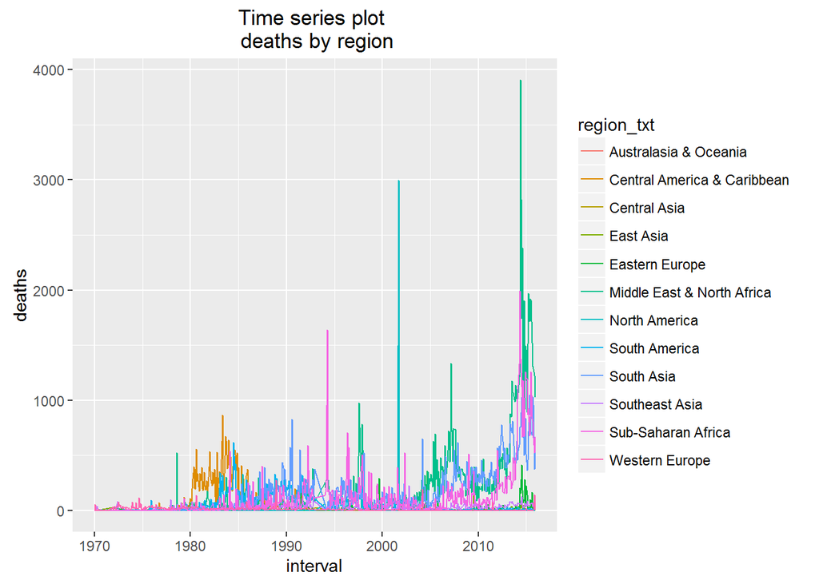

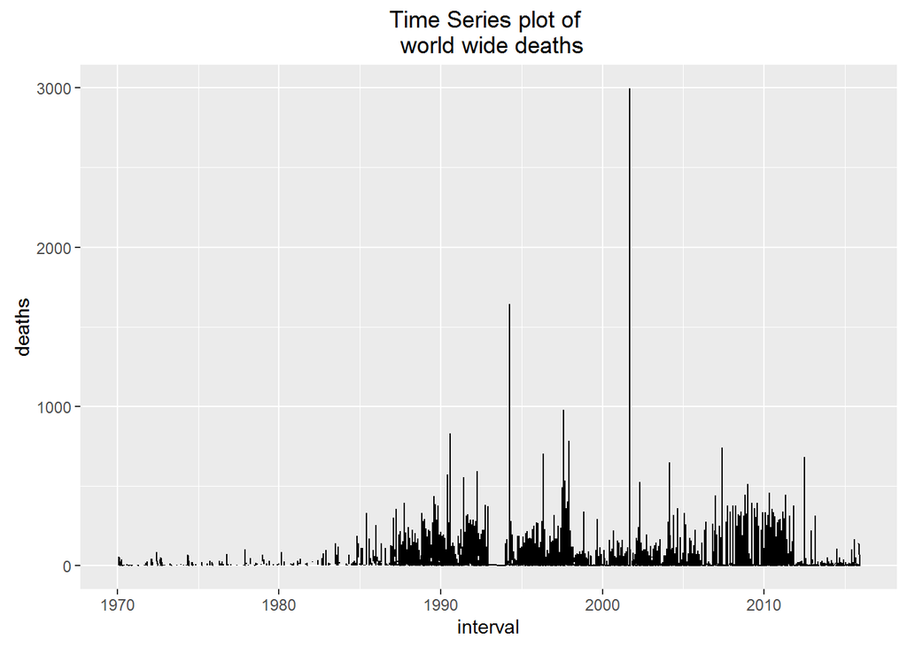

## Data displayed as time series by Year

Similarly we can see the global rise in terrorism by year since 1970. The pattern is even more clearer the time series of deaths by years and deaths by year and region is plotted. The below shot shows the number of deaths globally (not broken out by region). We see a rise in the late 1970’s and 1980’s which persisted till 2010 followed by a large increase thereafter.

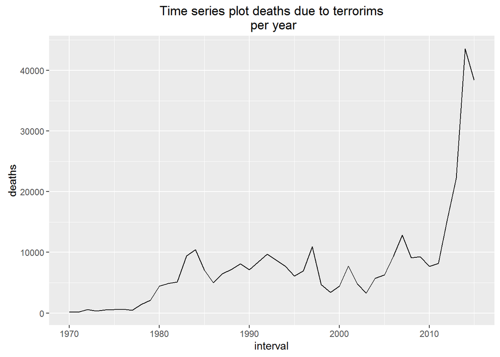

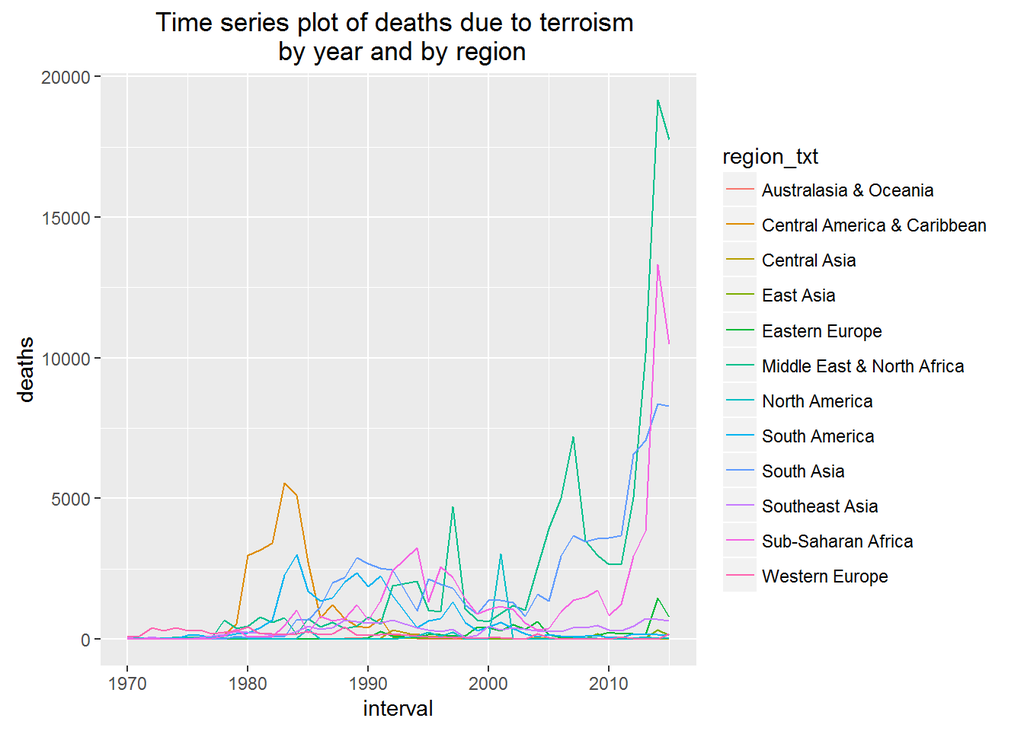

## Viewing deaths by region using stacked bar charts

Now lets look at the data as a stacked bar chart. When viewed as a stacked bar plot (with the region represented as portion of the bar). It is clear to see the fall off in terrororism in South America and Central america, corresponding with a rise in terrorism in the middle east. For the last decade the number of deaths that are due to terrorism has been dominated by south asia, the Middle East and Sub Saharan Africa.

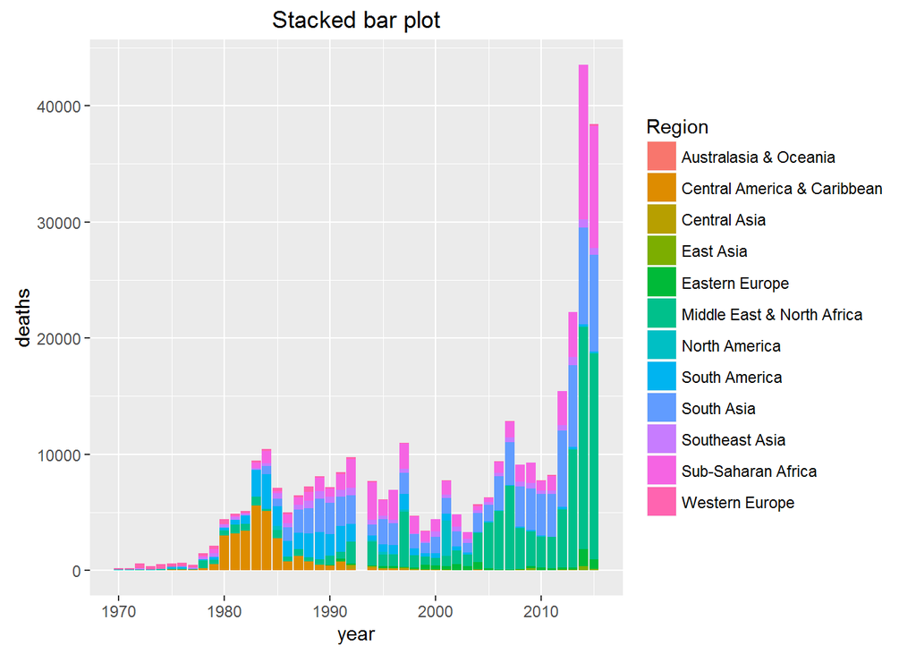

## Viewing deaths by countries in the middle east using stacked bar charts

Plotting the deaths of those killed from terrorism it’s quite clear that terrorism was really not a concern until after the invasion in 2003.

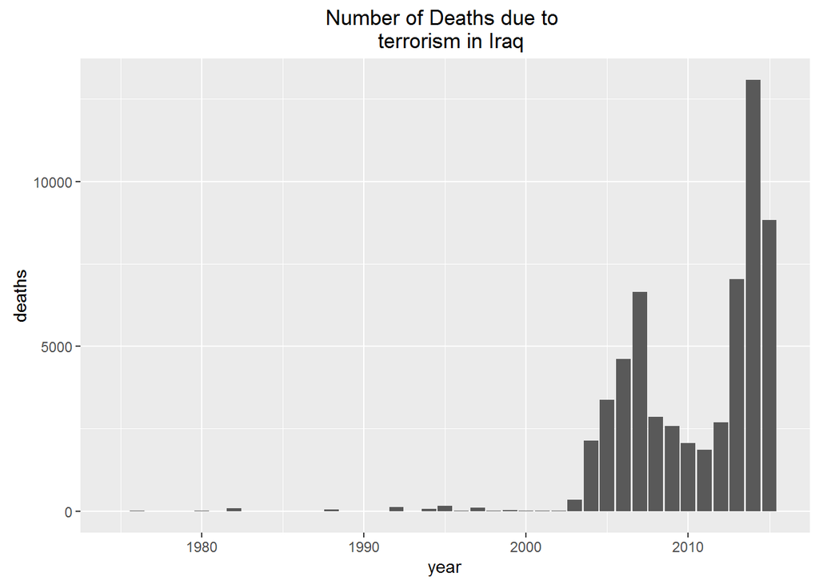

Syria shows a similar pattern there was a small outbreak of terrorism in 1981 due to the muslim brotherhood rising in 1981.

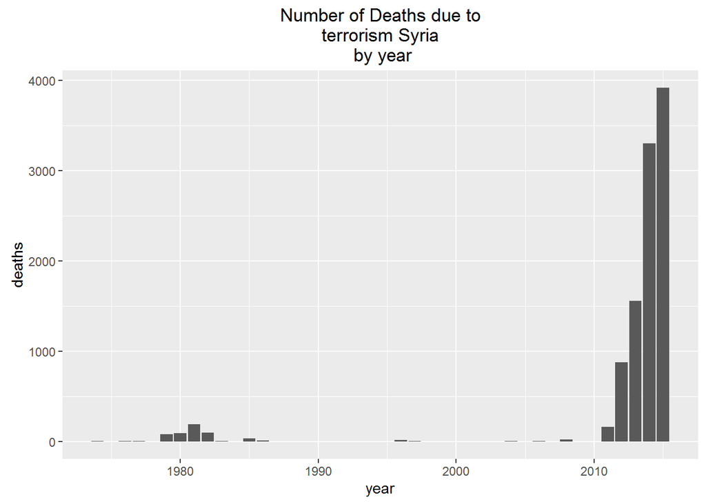

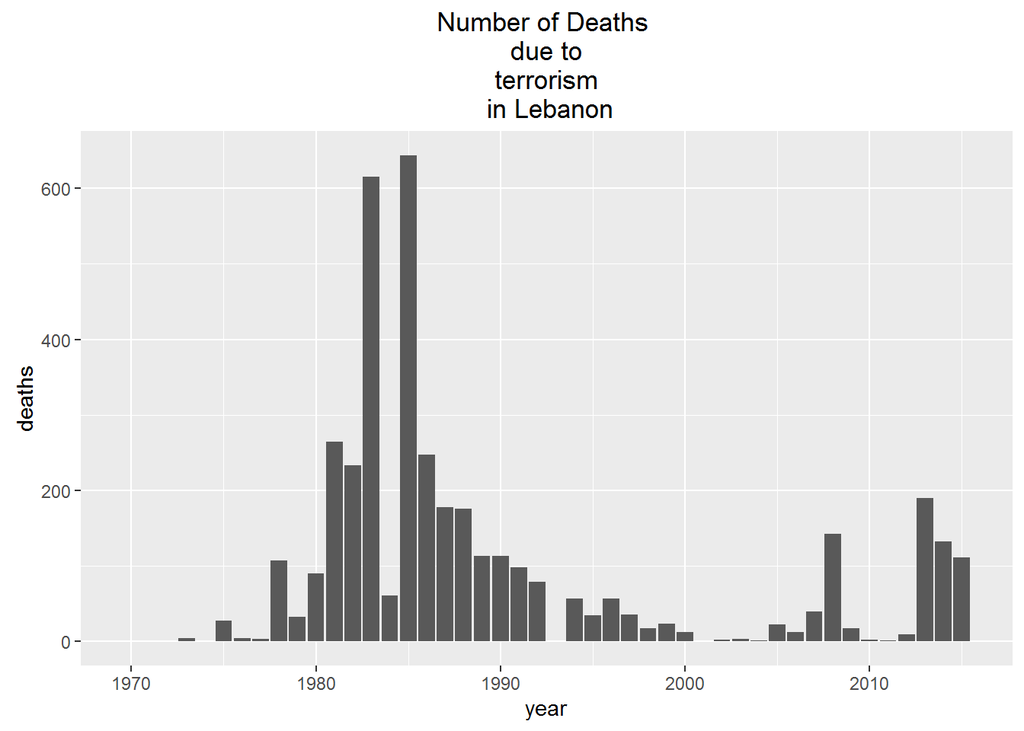

Similarly Turkey has seen a rise in deaths due to terrorism since the arab spring.

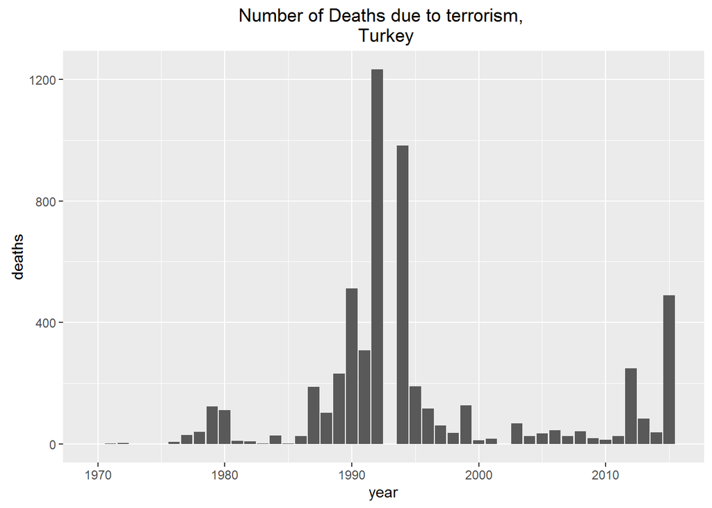

## Stacked bar plot of counts of deaths by year by country for the middle east

From looking at the whole middle east the number of deaths due to terrorism are increasing and are made up predominatly of fatalities from Iraq, Syria and Yemen.

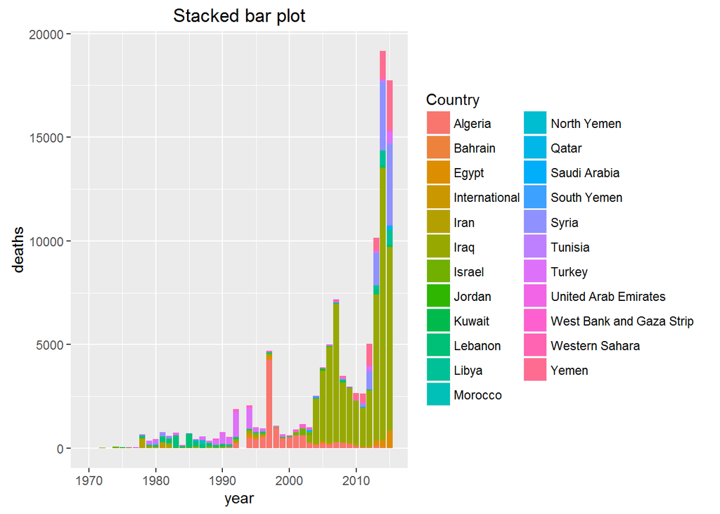

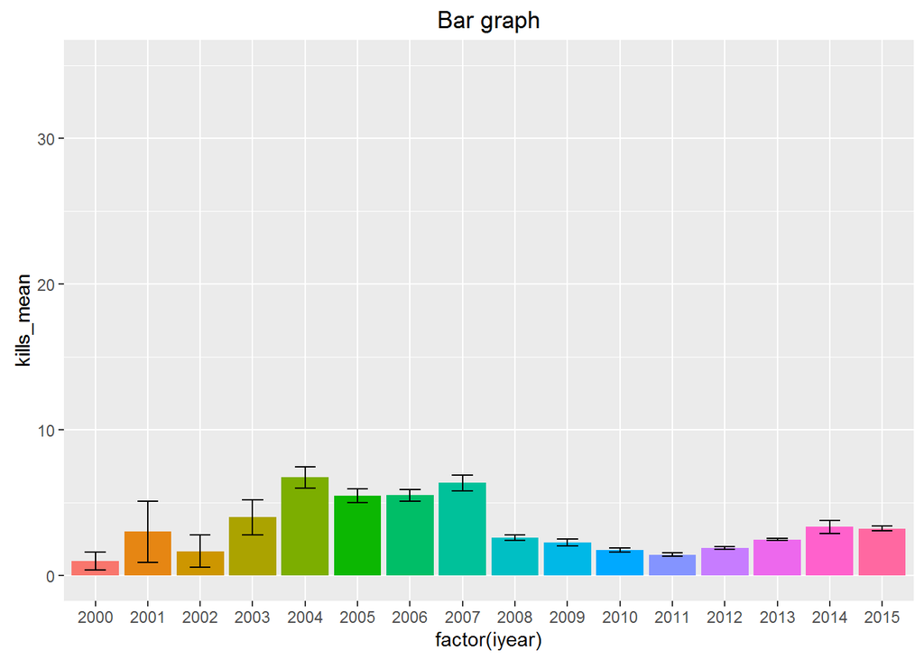

The daily number of deaths in Iraq due to terrorism since 1975

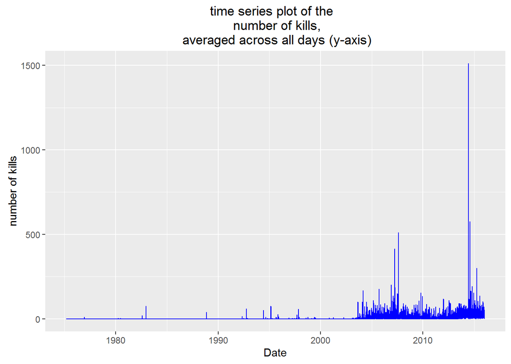

The daily counts are really interesting as we may be able to model this data usign some preliminary methods to get a sense of when the changes and what were the covariates of these events. To do this we use a two techniques Poisson Regression and Hidden markov Models: (a) The poisson model as we are modelling count data might be effective at modelling the numbers of dead killed per month and seeing if the different events that took place specifically interventions have an effect on lowering or increasing the death toll due to terrorism. (b) Hidden Markov Model might be useful at modelling the transition of Iraq from an era of realtive peace(low numbers of attack) to era’s with high number of terrorist attacks. This change in state from an era of peace to that of outright insurgency would ve very usefull to look at to examine when a particular change occurred. But also from a point of view if seeing if interventions had an effect and when after an intervention.

## Poisson regession

From the poisson model we can see the residual deviance is lower than the null deviance, however the model does not explain the deviance very well. We do not learn alot from this experiment except that the surge had a positive effect (increased the number killed) on the number of people killed. While the pullout (the period after the surge) saw a significant drop in the number of people killed due to terrorism.

```
##
## Call:
## glm(formula = kills_sum ~ ., family = "poisson", data = iraq.kills.summary.period)
##
## Deviance Residuals:
##     Min       1Q   Median       3Q      Max
## -19.415   -4.219   -1.867    2.302   71.652
##
## Coefficients:
##                       Estimate Std. Error z value Pr(>|z|)
## (Intercept)          1.4566812  0.1429542   10.19   <2e-16 ***
## month_since_1970     0.0097591  0.0003505   27.84   <2e-16 ***
## PeriodPost_Invasion  0.5147116  0.0228935   22.48   <2e-16 ***
## PeriodPostPullout    0.6263933  0.0276487   22.66   <2e-16 ***
## PeriodPre_Invasion  -1.8482094  0.0635771  -29.07   <2e-16 ***
## PeriodPullout       -0.5031853  0.0212600  -23.67   <2e-16 ***
## PeriodSurge          1.0782566  0.0194152   55.54   <2e-16 ***
## ---
## Signif. codes:  0 '***' 0.001 '**' 0.01 '*' 0.05 '.' 0.1 ' ' 1
##
## (Dispersion parameter for poisson family taken to be 1)
##
##     Null deviance: 94293  on 251  degrees of freedom
## Residual deviance: 18048  on 245  degrees of freedom
## AIC: 19401
##
## Number of Fisher Scoring iterations: 6
```

```
##
## Call:
## glm(formula = kills_sum ~ ., family = "quasipoisson", data = iraq.kills.summary.period)
##
## Deviance Residuals:
##     Min       1Q   Median       3Q      Max
## -19.415   -4.219   -1.867    2.302   71.652
##
## Coefficients:
##                      Estimate Std. Error t value Pr(>|t|)
## (Intercept)          1.456681   1.500151   0.971  0.33249
## month_since_1970     0.009759   0.003678   2.653  0.00850 **
## PeriodPost_Invasion  0.514712   0.240242   2.142  0.03314 *
## PeriodPostPullout    0.626393   0.290143   2.159  0.03183 *
## PeriodPre_Invasion  -1.848209   0.667174  -2.770  0.00603 **
## PeriodPullout       -0.503185   0.223101  -2.255  0.02499 *
## PeriodSurge          1.078257   0.203742   5.292 2.68e-07 ***
## ---
## Signif. codes:  0 '***' 0.001 '**' 0.01 '*' 0.05 '.' 0.1 ' ' 1
##
## (Dispersion parameter for quasipoisson family taken to be 110.1226)
##
##     Null deviance: 94293  on 251  degrees of freedom
## Residual deviance: 18048  on 245  degrees of freedom
## AIC: NA
##
## Number of Fisher Scoring iterations: 6
```

The plot of the predicted versus the actuals is shown below:

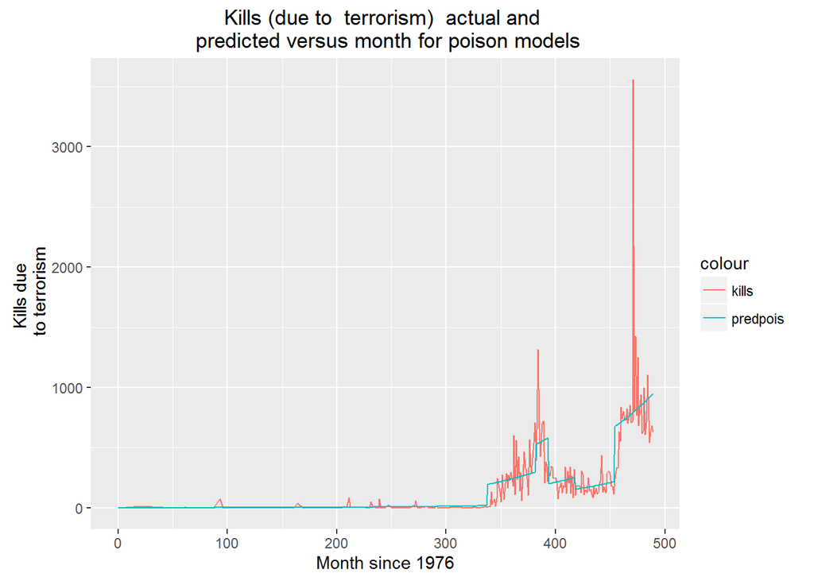

As we are seeing an increase incounts of deaths over time it may make sense to model this as a quadratic effect we do this below and we see and plot the results, doing so we see from the graph no better fit and also the model remins massively overdispersed.

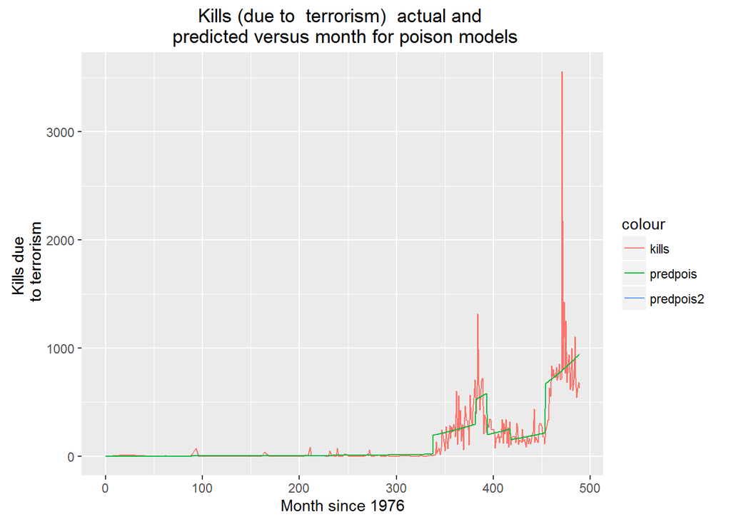

[output not shown]

## Hiden Markov Models

The two state model output is shown below. the summary of the model output can be seen.

```
## iteration 0 logLik: -16666.39
## iteration 5 logLik: -14811.46
## iteration 10 logLik: -14696.15
## iteration 15 logLik: -14667.42
## iteration 20 logLik: -14660.45
## iteration 25 logLik: -14658.61
## iteration 30 logLik: -14658.13
## iteration 35 logLik: -14658.01
## iteration 40 logLik: -14657.99
## iteration 45 logLik: -14657.98
## iteration 50 logLik: -14657.98
## converged at iteration 51 with logLik: -14657.98
```

```
## Response parameters
## Resp 1 : gaussian
##     Re1.(Intercept) Re1.sd
## St1          28.377 30.337
## St2           2.654  2.774
```

```
##   state         S1        S2
## 1     2 0.00000000 1.0000000
## 2     2 0.48370298 0.5162970
## 3     2 0.06537087 0.9346291
## 4     2 0.02324131 0.9767587
## 5     2 0.02614839 0.9738516
## 6     2 0.03331867 0.9666813
```

```
##        idate sum_kill
## 1 1975-03-01        0
## 2 1976-12-15       10
## 3 1976-12-18        0
## 4 1976-12-24        2
## 5 1979-06-15        1
## 6 1979-11-21        0
```

```
## [1] 3829
```

```
## [1] 3829
```

```
## 1 2 3 4 5 6
## 1 1 1 1 1 1
```